# Prosper Loan Data Exploration

## by Ebubechukwu Princewill Okoye

## Introduction

> This dataset is financial dataset and this is related to the loan, borrowers, lenders, interest rates and stuffs like that. Prosper or Prosper Marketplace Inc. is a San Francisco, California based company specializing in loans at low interest rates to the borrowers. In this dataset, we are using the data from the Posper to analyse it and trying to find the pattern in the Prosper data. This may be tedious because of the sheer size of the dataset and the complicated nature of all the financial datasets. The dataset is comprised of 81 variables and contains 113937 entries. These variables with their descriptions are listed below:

| Variable | Description |
| --- | --- |
| ListingKey | Unique key for each listing, same value as the 'key' used in the listing object in the API. |
| ListingNumber | The number that uniquely identifies the listing to the public as displayed on the website. |
| ListingCreationDate | The date the listing was created. |
| CreditGrade | The Credit rating that was assigned at the time the listing went live. Applicable for listings pre-2009 period and will only be populated for those listings. |
| Term | The length of the loan expressed in months. |
| LoanStatus | The current status of the loan: Cancelled, Chargedoff, Completed, Current, Defaulted, FinalPaymentInProgress, PastDue. The PastDue status will be accompanied by a delinquency bucket. |
| ClosedDate | Closed date is applicable for Cancelled, Completed, Chargedoff and Defaulted loan statuses. |
| BorrowerAPR | The Borrower's Annual Percentage Rate (APR) for the loan. |
| BorrowerRate | The Borrower's interest rate for this loan. |
| LenderYield | The Lender yield on the loan. Lender yield is equal to the interest rate on the loan less the servicing fee. |
| EstimatedEffectiveYield | Effective yield is equal to the borrower interest rate (i) minus the servicing fee rate, (ii) minus estimated uncollected interest on charge-offs, (iii) plus estimated collected late fees. Applicable … |
| EstimatedLoss | Estimated loss is the estimated principal loss on charge-offs. Applicable for loans originated after July 2009. |
| EstimatedReturn | The estimated return assigned to the listing at the time it was created. Estimated return is the difference between the Estimated Effective Yield and the Estimated Loss Rate. Applicable for loans orig… |
| ProsperRating (numeric) | The Prosper Rating assigned at the time the listing was created: 0 - N/A, 1 - HR, 2 - E, 3 - D, 4 - C, 5 - B, 6 - A, 7 - AA. Applicable for loans originated after July 2009. |
| ProsperRating (Alpha) | The Prosper Rating assigned at the time the listing was created between AA - HR. Applicable for loans originated after July 2009. |
| ProsperScore | A custom risk score built using historical Prosper data. The score ranges from 1-10, with 10 being the best, or lowest risk score. Applicable for loans originated after July 2009. |
| ListingCategory | The category of the listing that the borrower selected when posting their listing: 0 - Not Available, 1 - Debt Consolidation, 2 - Home Improvement, 3 - Business, 4 - Personal Loan, 5 - Student Use, 6 … |
| BorrowerState | The two letter abbreviation of the state of the address of the borrower at the time the Listing was created. |
| Occupation | The Occupation selected by the Borrower at the time they created the listing. |
| EmploymentStatus | The employment status of the borrower at the time they posted the listing. |
| EmploymentStatusDuration | The length in months of the employment status at the time the listing was created. |
| IsBorrowerHomeowner | A Borrower will be classified as a homowner if they have a mortgage on their credit profile or provide documentation confirming they are a homeowner. |
| CurrentlyInGroup | Specifies whether or not the Borrower was in a group at the time the listing was created. |
| GroupKey | The Key of the group in which the Borrower is a member of. Value will be null if the borrower does not have a group affiliation. |
| DateCreditPulled | The date the credit profile was pulled. |
| CreditScoreRangeLower | The lower value representing the range of the borrower's credit score as provided by a consumer credit rating agency. |
| CreditScoreRangeUpper | The upper value representing the range of the borrower's credit score as provided by a consumer credit rating agency. |
| FirstRecordedCreditLine | The date the first credit line was opened. |
| CurrentCreditLines | Number of current credit lines at the time the credit profile was pulled. |
| OpenCreditLines | Number of open credit lines at the time the credit profile was pulled. |

[output cut: 51 more lines]

## Preliminary Wrangling

```python
# import all packages and set plots to be embedded inline
import numpy as np
import pandas as pd
import matplotlib.pyplot as plt
import seaborn as sb

%matplotlib inline
```

> Load in your dataset and describe its properties through the questions below. Try and motivate your exploration goals through this section.

```python
#load in and view the dataset
prosper_loan = pd.read_csv('prosperloanData.csv')
prosper_loan.head()
```

|  | ListingKey | ListingNumber | ListingCreationDate | CreditGrade | Term | LoanStatus | ClosedDate | BorrowerAPR | BorrowerRate | LenderYield | ... | LP_ServiceFees | LP_CollectionFees | LP_GrossPrincipalLoss | LP_NetPrincipalLoss | LP_NonPrincipalRecoverypayments | PercentFunded | Recommendations | InvestmentFromFriendsCount | InvestmentFromFriendsAmount | Investors |
| --- | --- | --- | --- | --- | --- | --- | --- | --- | --- | --- | --- | --- | --- | --- | --- | --- | --- | --- | --- | --- | --- |
| 0 | 1021339766868145413AB3B | 193129 | 09:29.3 | C | 36 | Completed | 8/14/2009 0:00 | 0.16516 | 0.1580 | 0.1380 | ... | -133.18 | 0.0 | 0.0 | 0.0 | 0.0 | 1.0 | 0 | 0 | 0.0 | 258 |
| 1 | 10273602499503308B223C1 | 1209647 | 28:07.9 | NaN | 36 | Current | NaN | 0.12016 | 0.0920 | 0.0820 | ... | 0.00 | 0.0 | 0.0 | 0.0 | 0.0 | 1.0 | 0 | 0 | 0.0 | 1 |
| 2 | 0EE9337825851032864889A | 81716 | 00:47.1 | HR | 36 | Completed | 12/17/2009 0:00 | 0.28269 | 0.2750 | 0.2400 | ... | -24.20 | 0.0 | 0.0 | 0.0 | 0.0 | 1.0 | 0 | 0 | 0.0 | 41 |
| 3 | 0EF5356002482715299901A | 658116 | 02:35.0 | NaN | 36 | Current | NaN | 0.12528 | 0.0974 | 0.0874 | ... | -108.01 | 0.0 | 0.0 | 0.0 | 0.0 | 1.0 | 0 | 0 | 0.0 | 158 |
| 4 | 0F023589499656230C5E3E2 | 909464 | 38:39.1 | NaN | 36 | Current | NaN | 0.24614 | 0.2085 | 0.1985 | ... | -60.27 | 0.0 | 0.0 | 0.0 | 0.0 | 1.0 | 0 | 0 | 0.0 | 20 |

5 rows × 81 columns

```python
#Overview of data shape and composition
print(prosper_loan.shape)
print(prosper_loan.info())
```

```
(113937, 81)
<class 'pandas.core.frame.DataFrame'>
RangeIndex: 113937 entries, 0 to 113936
Data columns (total 81 columns):
 #   Column                               Non-Null Count   Dtype
---  ------                               --------------   -----
 0   ListingKey                           113937 non-null  object
 1   ListingNumber                        113937 non-null  int64
 2   ListingCreationDate                  113937 non-null  object
 3   CreditGrade                          28953 non-null   object
 4   Term                                 113937 non-null  int64
 5   LoanStatus                           113937 non-null  object
 6   ClosedDate                           55089 non-null   object
 7   BorrowerAPR                          113912 non-null  float64
 8   BorrowerRate                         113937 non-null  float64
```

[output cut: 75 more lines]

```python
#Descriptive statistics for numeric variables
prosper_loan.describe()
```

|  | ListingNumber | Term | BorrowerAPR | BorrowerRate | LenderYield | EstimatedEffectiveYield | EstimatedLoss | EstimatedReturn | ProsperRating (numeric) | ProsperScore | ... | LP_ServiceFees | LP_CollectionFees | LP_GrossPrincipalLoss | LP_NetPrincipalLoss | LP_NonPrincipalRecoverypayments | PercentFunded | Recommendations | InvestmentFromFriendsCount | InvestmentFromFriendsAmount | Investors |
| --- | --- | --- | --- | --- | --- | --- | --- | --- | --- | --- | --- | --- | --- | --- | --- | --- | --- | --- | --- | --- | --- |
| count | 1.139370e+05 | 113937.000000 | 113912.000000 | 113937.000000 | 113937.000000 | 84853.000000 | 84853.000000 | 84853.000000 | 84853.000000 | 84853.000000 | ... | 113937.000000 | 113937.000000 | 113937.000000 | 113937.000000 | 113937.000000 | 113937.000000 | 113937.000000 | 113937.000000 | 113937.000000 | 113937.000000 |
| mean | 6.278857e+05 | 40.830248 | 0.218828 | 0.192764 | 0.182701 | 0.168661 | 0.080306 | 0.096068 | 4.072243 | 5.950067 | ... | -54.725641 | -14.242698 | 700.446342 | 681.420499 | 25.142686 | 0.998584 | 0.048027 | 0.023460 | 16.550751 | 80.475228 |
| std | 3.280762e+05 | 10.436212 | 0.080364 | 0.074818 | 0.074516 | 0.068467 | 0.046764 | 0.030403 | 1.673227 | 2.376501 | ... | 60.675425 | 109.232758 | 2388.513831 | 2357.167068 | 275.657937 | 0.017919 | 0.332353 | 0.232412 | 294.545422 | 103.239020 |
| min | 4.000000e+00 | 12.000000 | 0.006530 | 0.000000 | -0.010000 | -0.182700 | 0.004900 | -0.182700 | 1.000000 | 1.000000 | ... | -664.870000 | -9274.750000 | -94.200000 | -954.550000 | 0.000000 | 0.700000 | 0.000000 | 0.000000 | 0.000000 | 1.000000 |
| 25% | 4.009190e+05 | 36.000000 | 0.156290 | 0.134000 | 0.124200 | 0.115670 | 0.042400 | 0.074080 | 3.000000 | 4.000000 | ... | -73.180000 | 0.000000 | 0.000000 | 0.000000 | 0.000000 | 1.000000 | 0.000000 | 0.000000 | 0.000000 | 2.000000 |
| 50% | 6.005540e+05 | 36.000000 | 0.209760 | 0.184000 | 0.173000 | 0.161500 | 0.072400 | 0.091700 | 4.000000 | 6.000000 | ... | -34.440000 | 0.000000 | 0.000000 | 0.000000 | 0.000000 | 1.000000 | 0.000000 | 0.000000 | 0.000000 | 44.000000 |
| 75% | 8.926340e+05 | 36.000000 | 0.283810 | 0.250000 | 0.240000 | 0.224300 | 0.112000 | 0.116600 | 5.000000 | 8.000000 | ... | -13.920000 | 0.000000 | 0.000000 | 0.000000 | 0.000000 | 1.000000 | 0.000000 | 0.000000 | 0.000000 | 115.000000 |
| max | 1.255725e+06 | 60.000000 | 0.512290 | 0.497500 | 0.492500 | 0.319900 | 0.366000 | 0.283700 | 7.000000 | 11.000000 | ... | 32.060000 | 0.000000 | 25000.000000 | 25000.000000 | 21117.900000 | 1.012500 | 39.000000 | 33.000000 | 25000.000000 | 1189.000000 |

8 rows × 61 columns

```python
#Change column names to lower case formats all-through
prosper_loan = prosper_loan.rename(columns = lambda x:x.lower())

#Checking
prosper_loan.head()
```

|  | listingkey | listingnumber | listingcreationdate | creditgrade | term | loanstatus | closeddate | borrowerapr | borrowerrate | lenderyield | ... | lp_servicefees | lp_collectionfees | lp_grossprincipalloss | lp_netprincipalloss | lp_nonprincipalrecoverypayments | percentfunded | recommendations | investmentfromfriendscount | investmentfromfriendsamount | investors |
| --- | --- | --- | --- | --- | --- | --- | --- | --- | --- | --- | --- | --- | --- | --- | --- | --- | --- | --- | --- | --- | --- |
| 0 | 1021339766868145413AB3B | 193129 | 09:29.3 | C | 36 | Completed | 8/14/2009 0:00 | 0.16516 | 0.1580 | 0.1380 | ... | -133.18 | 0.0 | 0.0 | 0.0 | 0.0 | 1.0 | 0 | 0 | 0.0 | 258 |
| 1 | 10273602499503308B223C1 | 1209647 | 28:07.9 | NaN | 36 | Current | NaN | 0.12016 | 0.0920 | 0.0820 | ... | 0.00 | 0.0 | 0.0 | 0.0 | 0.0 | 1.0 | 0 | 0 | 0.0 | 1 |
| 2 | 0EE9337825851032864889A | 81716 | 00:47.1 | HR | 36 | Completed | 12/17/2009 0:00 | 0.28269 | 0.2750 | 0.2400 | ... | -24.20 | 0.0 | 0.0 | 0.0 | 0.0 | 1.0 | 0 | 0 | 0.0 | 41 |
| 3 | 0EF5356002482715299901A | 658116 | 02:35.0 | NaN | 36 | Current | NaN | 0.12528 | 0.0974 | 0.0874 | ... | -108.01 | 0.0 | 0.0 | 0.0 | 0.0 | 1.0 | 0 | 0 | 0.0 | 158 |
| 4 | 0F023589499656230C5E3E2 | 909464 | 38:39.1 | NaN | 36 | Current | NaN | 0.24614 | 0.2085 | 0.1985 | ... | -60.27 | 0.0 | 0.0 | 0.0 | 0.0 | 1.0 | 0 | 0 | 0.0 | 20 |

5 rows × 81 columns

### What is the structure of your dataset?

> There are 113937 entries in the dataset with 81 features. Most variables are numeric in nature, while the remaining are categorical.

### What is/are the main feature(s) of interest in your dataset?

> i'm interested to know what features affects the loan status, original loan amount applied for, and loan term of borrowers. I also want to see how these features are related to one another.

### What features in the dataset do you think will help support your investigation into your feature(s) of interest?

> I think these features; Is borrower a home owner, employment status, income verifiable, listing category,stated monthly income, investors, and recommendations, will help me in my investigation.

## Univariate Exploration

I will start by looking at the distribution of the main variables of interest: Loan original amount, loan status, and loan term.

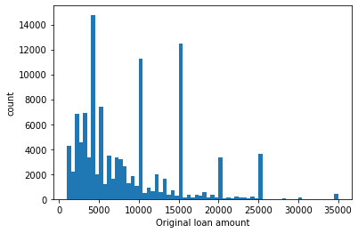

```python
# Wrapping my histogram plot in a function to avoid repetition
def histchart(column, x_label, bin_edge):
    plt.hist(prosper_loan[column], bins = bin_edge)
    plt.xlabel(x_label)
    plt.ylabel('count');

# Plotting the distribution of original loan amount
bin_edge = np.arange(1000, prosper_loan.loanoriginalamount.max()+500, 500)
histchart('loanoriginalamount', 'Original loan amount', bin_edge)
```

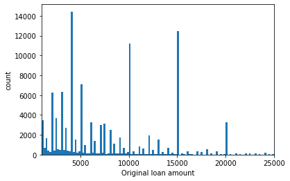

```python
#Investigating further on an even smaller bin
bin_edge = np.arange(1000, prosper_loan.loanoriginalamount.max()+200, 200)
histchart('loanoriginalamount', 'Original loan amount', bin_edge)
plt.xlim([1000, 25000]);
```

> There seem to be very large spikes in frequency at the bars with rounded numbers (e.g. 4000, 5000, 10000, etc). This is probably because people are unconsciously drawn to rounded numbers, especially when money is involved.

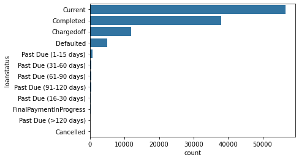

```python
# let's see What loan status occured the most?
# And the order of occurence in a decreasing manner
base_color = sb.color_palette()[0]
order = prosper_loan.loanstatus.value_counts().index
sb.countplot(data = prosper_loan, y = 'loanstatus', color = base_color, order = order);
```

> From the barchart, it can be seen that the loan status of most persons at the time the data was pulled is current.

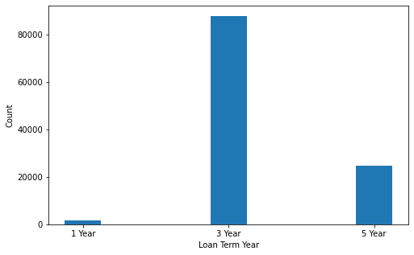

```python
# Plot a barchart to see what loan term in years that people applied for the most
term_count = prosper_loan.groupby('term').size()
plt.figure(figsize=[8,5])
plt.bar(term_count.index, term_count, width = 6)
plt.xticks([12, 36, 60], ['1 Year', '3 Year', '5 Year'])
plt.xlabel('Loan Term Year')
plt.ylabel('Count');
```

> The barchart showed that people applied more for a 3 year(36 months) loan term or medium term loan and also applied least for the short term loan. Does this mean that people that apply for 3 year loan term pay up more?

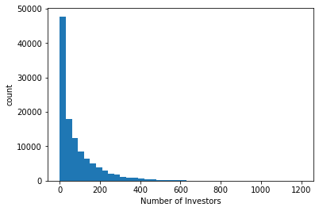

```python
# Viewing the distribution of investors
bin_edge = np.arange(0, prosper_loan.investors.max()+30, 30)
histchart('investors', 'Number of Investors', bin_edge)
```

> This chart is skewed to the right. Let's put it on a log scale.

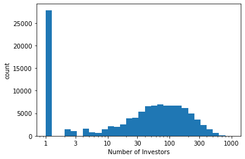

```python
#plotting the investors feature on a log scale
bin_edge = np.power(10, np.arange(0, np.log10(prosper_loan.investors.max()+0.1), 0.1))
histchart('investors', 'Number of Investors', bin_edge)
ticks = [1, 3, 10, 30, 100, 300, 1000]
plt.xscale('log')
plt.xticks(ticks, ticks);
```

Why do people generally take out loan? what reason is more prevalent? The column holding this information has all it's categorical data mapped to a number.

0 - Not Available, 1 - Debt Consolidation, 2 - Home Improvement, 3 - Business, 4 - Personal Loan, 5 - Student Use, 6 - Auto, 7- Other, 8 - Baby&Adoption, 9 - Boat, 10 - Cosmetic Procedure, 11 - Engagement Ring, 12 - Green Loans, 13 - Household Expenses, 14 - Large Purchases, 15 - Medical/Dental, 16 - Motorcycle, 17 - RV, 18 - Taxes, 19 - Vacation, 20 - Wedding Loans

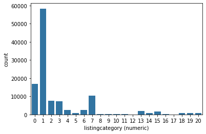

```python
#plotting a barchart of listing category
sb.countplot(data = prosper_loan, x = 'listingcategory (numeric)', color = base_color);
```

> It seems that more people applied for loan in order to settle debts.

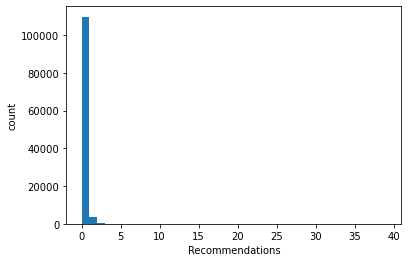

```python
#plotting the distribution of recommendations
bin_edge = np.arange(0, prosper_loan.recommendations.max()+1, 1)
histchart('recommendations', 'Recommendations', bin_edge)
```

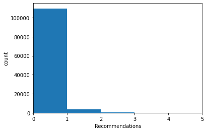

```python
# investigating further with smaller xlimits
bin_edge = np.arange(0, prosper_loan.recommendations.max()+1, 1)
histchart('recommendations', 'Recommendations', bin_edge)
plt.xlim([0, 5]);
```

> This shows that majority of the borrowers had no prior recommendations. For those that were recommended, most were only recommended once.

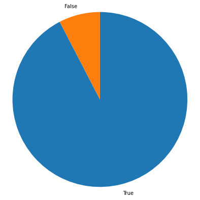

```python
# To see the percentage of indviduals that applied for loan
# with a verifiable income document
sorted_counts = prosper_loan.incomeverifiable.value_counts()
total_count = prosper_loan.incomeverifiable.value_counts().sum()
sorted_counts_percent = (sorted_counts/total_count)*100
plt.figure(figsize=[7,7])
plt.pie(sorted_counts_percent, labels = sorted_counts_percent.index, startangle = 90, counterclock = False)
plt.axis('square');
```

> It can be seen that greater percentage of individuals provided a document to verify their income claims.

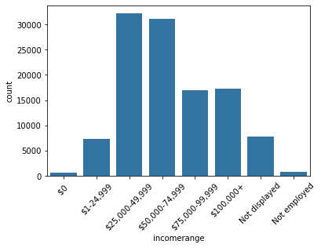

```python
#plot a barchart for income range of borrowers
order = ['$0 ', '$1-24,999', '$25,000-49,999', '$50,000-74,999',
       '$75,000-99,999','$100,000+', 'Not displayed', 'Not employed'] #creating an order for the plot
sb.countplot(data = prosper_loan, x = 'incomerange', color = base_color, order = order)
plt.xticks(rotation=45);
```

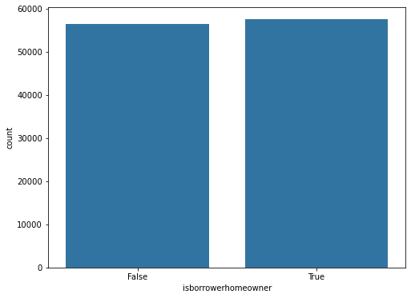

```python
# Plot a barchart to see how many of the borrowers were home owners
plt.figure(figsize=(8,6))
sb.countplot(data = prosper_loan, x = 'isborrowerhomeowner', color = base_color);
```

> There is very little different between the numbers of those that own a home and those that don't.

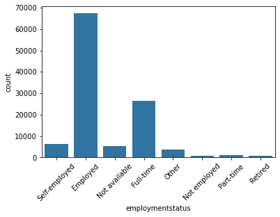

```python
#let's see the distribution of the employment status column
sb.countplot(data = prosper_loan, x = 'employmentstatus', color = base_color)
plt.xticks(rotation=45);
```

> A great number of persons that applied for loans were employed.

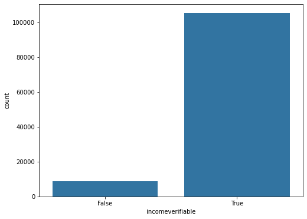

```python
plt.figure(figsize=(8,6))
sb.countplot(data = prosper_loan, x = 'incomeverifiable', color = base_color);
```

> From the barchart, we can see more persons applied for loan with a verifiable income document.

## Bivariate Exploration

> Let's start with looking at the pairwise correlation between numeric variables in the dataset.

```python
numeric_vars = ['investors', 'loanoriginalamount', 'recommendations']
```

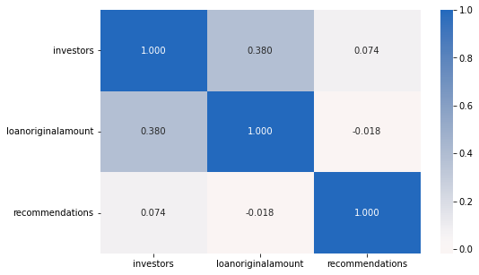

```python
# correlation plot
plt.figure(figsize = [8, 5])
sb.heatmap(prosper_loan[numeric_vars].corr(), annot = True, fmt = '.3f', cmap = 'vlag_r', center = 0);
```

```
prosper_loan.shape= (113937, 81)
prosper_loan_samp.shape= (1000, 81)
```

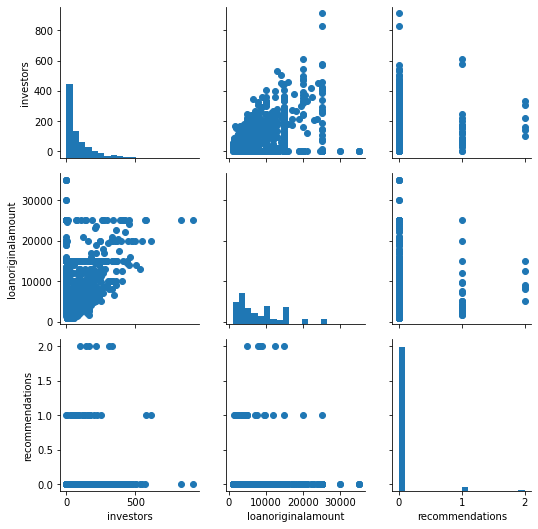

```python
# plot matrix: sample 1000 entries so that plots are clearer and they render faster
print("prosper_loan.shape=",prosper_loan.shape)
prosper_loan_samp = prosper_loan.sample(n=1000, replace = False)
print("prosper_loan_samp.shape=",prosper_loan_samp.shape)


g =sb.PairGrid(data = prosper_loan_samp, vars = numeric_vars)
g.map_offdiag(plt.scatter)
g.map_diag(plt.hist, bins = 20);
```

> There is a weak positive correlation between investors and loan original amount. This suggests that higher loan amounts had higher number of investors. There is also a very weak correlation between investors and recommendations(This is not easily seen in the scatter plot but the heatmap above).

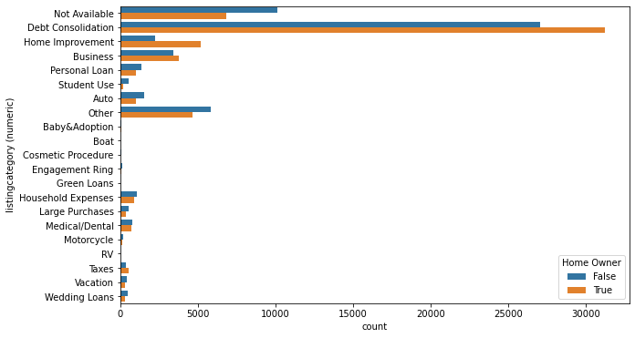

```python
#Check the relationship between listing category and home owners
plt.figure(figsize=[10,6])
sb.countplot(data = prosper_loan, y = 'listingcategory (numeric)', hue = 'isborrowerhomeowner')
locations = [0, 1, 2, 3, 4, 5, 6, 7, 8, 9, 10, 11, 12, 13, 14, 15, 16, 17, 18, 19, 20]
labels = ['Not Available', 'Debt Consolidation', 'Home Improvement', 'Business', 'Personal Loan', 'Student Use', 'Auto',
          'Other', 'Baby&Adoption', 'Boat', 'Cosmetic Procedure', 'Engagement Ring', 'Green Loans', 'Household Expenses',
          'Large Purchases', 'Medical/Dental', 'Motorcycle', 'RV', 'Taxes', 'Vacation', 'Wedding Loans']
plt.yticks(locations, labels)
plt.legend(title = 'Home Owner');
```

> You can notice a general trend where there are more borrowers that are not home owners in each listing category, with the exception of debt consolidation, home improvement(expected), business, and Taxes.

**Those with the cancelled loan status, does it have anything to do with low number of investors?**

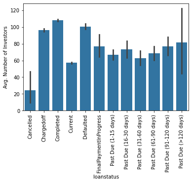

```python
# Adapting a barchart to plot for the average number
# of investors for each loan status
order = prosper_loan.groupby('loanstatus').size().index
sb.barplot(data = prosper_loan, x = 'loanstatus', y = 'investors', color = base_color, order = order)
plt.ylabel('Avg. Number of Investors')
plt.xticks(rotation=90);
```

> Like i suspected, the loan applications that were cancelled had the lowest number of investors.

**Now, to investigate the relationship between loan status and some categorical features.**

```python
#wrapping my countplot in a function to avoid repetition
def clustered_bar(column, hue_column, order):
    plt.figure(figsize = [10,7])
    sb.countplot(data = prosper_loan, x = column, hue = hue_column, order = order);
```

```python
#wrapping my heatmap plot in a function to avoid repetition
def heatmap(data):
    plt.figure(figsize = [10,7])
    sb.heatmap(data, annot = True, fmt = '.0f');
```

```python
#wrapping my boxplot in a function to avoid repetition
def box_plot(x_col, y_col, order_col):
    plt.figure(figsize = (8,6))
    sb.boxplot(data = prosper_loan, x = x_col, y = y_col, color = base_color, order = prosper_loan.groupby(order_col).size().index);
```

**Does income range affects whether an individual gets the loan?**

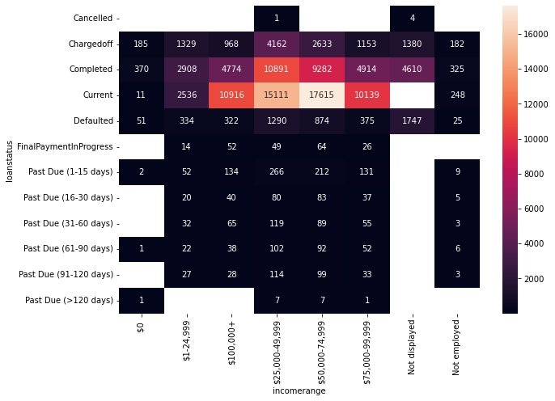

```python
#Investigating the relationship between loan status and income range
#summarising the counts into a matrix that can be plotted via heatmap
ct_counts = prosper_loan.groupby(['loanstatus','incomerange']).size()
ct_counts = ct_counts.reset_index(name = 'count')
#pivot the counts dataframe
ct_counts = ct_counts.pivot(index = 'loanstatus', columns = 'incomerange', values = 'count')

#plotting the heatmap
heatmap(ct_counts)
```

**What of the effect of employment status on loan status?**

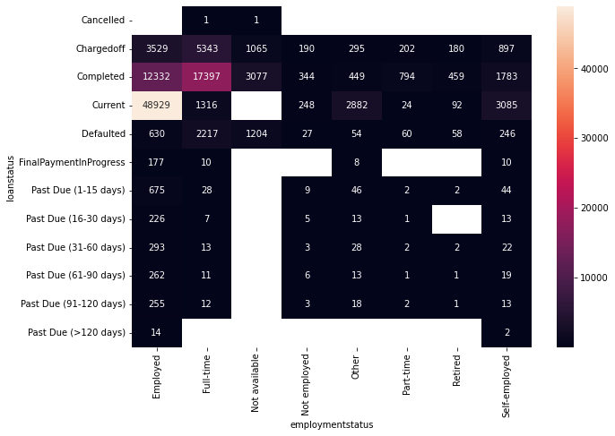

```python
#Checking the relationship between loan status and employmentstatus
#summarising the counts into a matrix that can be plotted via heatmap
ct_counts = prosper_loan.groupby(['loanstatus','employmentstatus']).size()
ct_counts = ct_counts.reset_index(name = 'count')
#pivot the counts dataframe
ct_counts = ct_counts.pivot(index = 'loanstatus', columns = 'employmentstatus', values = 'count')

#plotting the heatmap
heatmap(ct_counts)
```

> Most individuals Employed or working full-time had a loan status of current and completed. I also noticed that those that didn't provide their employment status at the time the data was pulled were not under the current loan status, but some are found under the completed loan status.

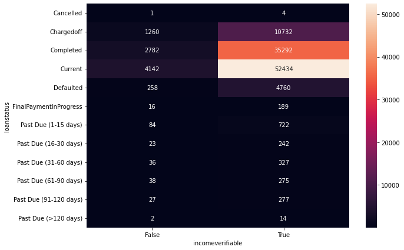

```python
#Investigating the relationship between loan status and income verifiable
#summarising the counts into a matrix that can be plotted via heatmap
ct_counts = prosper_loan.groupby(['loanstatus','incomeverifiable']).size()
ct_counts = ct_counts.reset_index(name = 'count')
#pivot the counts dataframe
ct_counts = ct_counts.pivot(index = 'loanstatus', columns = 'incomeverifiable', values = 'count')

#plotting the heatmap
heatmap(ct_counts)
```

```python
#investigating further using proportions, since there are far way more persons
# with a verifiable income document as seen in the univariate exploration section
verified_income_count = prosper_loan.groupby(['incomeverifiable', 'loanstatus']).size()
verified_income_total = prosper_loan.groupby('incomeverifiable').size()

#Getting the proportion of those with no verifiable document for each loan status
unverified_proportion = verified_income_count[0]/verified_income_total[0]


#Getting the proportion of those with a verifiable document for each loan status
verified_proportion = verified_income_count[1]/verified_income_total[1]

width = 0.35
index = np.arange(len(verified_proportion))
```

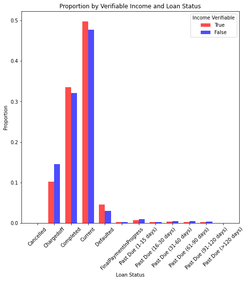

```python
#Using matplotlib.pyplot, plot a barchart to express proportions
plt.figure(figsize = (8,8))     #Figure size
verified_bar = plt.bar(index, verified_proportion, width, color = 'r', alpha = .7, label = 'True')
male_bar = plt.bar(index+width, unverified_proportion, width, color = 'b', alpha = .7, label = 'False')
plt.xlabel('Loan Status')
plt.ylabel('Proportion')
plt.title('Proportion by Verifiable Income and Loan Status')
plt.legend(title = 'Income Verifiable')
#xticks location
locations = index + width / 2
#xticks label
labels = prosper_loan.groupby('loanstatus').size().index
plt.xticks(locations, labels, rotation=45);
```

> From the heatmap we can see that a larger number of individuals under the current loan status had a verifiable income document, but this is not enough as there are far way more persons with a verifiable income document in the univariate section. The proportion barchart shows it all, indicating that the proportion of those with a verifiable income is higher than the proportion of those with none in the current and completed loan status.

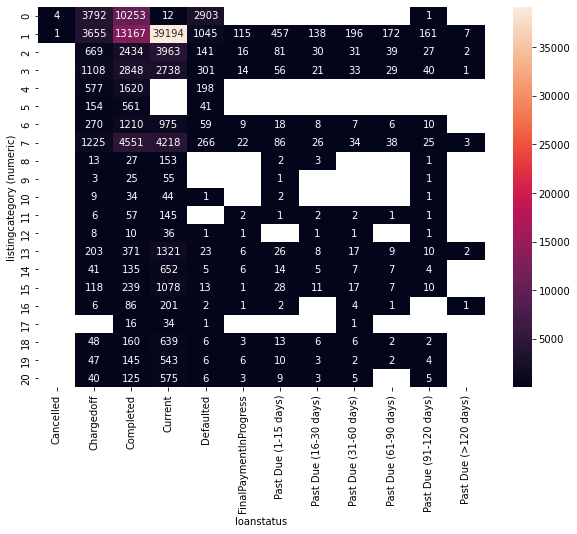

```python
#Investigating the relationship between loan status and listing category
#summarising the counts into a matrix that can be plotted via heatmap
ct_counts = prosper_loan.groupby(['loanstatus','listingcategory (numeric)']).size()
ct_counts = ct_counts.reset_index(name = 'count')
#pivot the counts dataframe
ct_counts = ct_counts.pivot(index = 'listingcategory (numeric)', columns = 'loanstatus', values = 'count')

#plotting the heatmap
heatmap(ct_counts)
```

> From this heatmap, we can see that very few loans were cancelled using the listing category as a basis. And out of the many persons on current loan status, very few(only 12) persons that didn't indicate a reason were granted loans.Also those under the the personal loan(4) and student loan(5) were not on current loan status. This could be driven by something else.

**Does income range of borrowers affect the term of loan they apply for?**

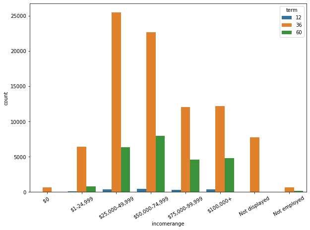

```python
order = order = ['$0 ', '$1-24,999', '$25,000-49,999', '$50,000-74,999',
       '$75,000-99,999','$100,000+', 'Not displayed', 'Not employed']
clustered_bar('incomerange', 'term', order)
plt.xticks(rotation = 30);
```

> It seems that borrowers applied more for medium term loans(36months) followed by long term loans(60months) despite their income range.

**Owning a home, does it affect the loan amount borrowers request for?**

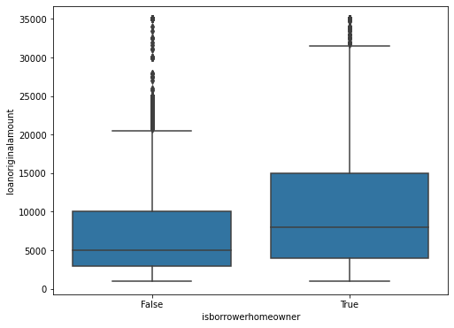

```python
box_plot('isborrowerhomeowner', 'loanoriginalamount', 'isborrowerhomeowner')
```

> The median loan amount requested from individuals that own a home is higher than their counterpart. The same goes for the upper limit. This goes to say that at the time this data was pulled, individuals that own a home applied for higher amount of loan.

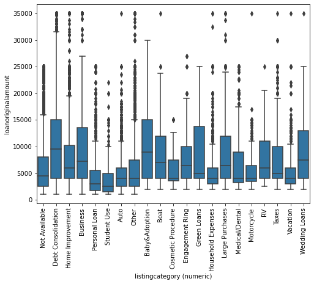

```python
#investigating relationships between listing category and original loan amount
box_plot('listingcategory (numeric)', 'loanoriginalamount', 'listingcategory (numeric)')
locations = [0, 1, 2, 3, 4, 5, 6, 7, 8, 9, 10, 11, 12, 13, 14, 15, 16, 17, 18, 19, 20]
labels = ['Not Available', 'Debt Consolidation', 'Home Improvement', 'Business', 'Personal Loan', 'Student Use', 'Auto',
          'Other', 'Baby&Adoption', 'Boat', 'Cosmetic Procedure', 'Engagement Ring', 'Green Loans', 'Household Expenses',
          'Large Purchases', 'Medical/Dental', 'Motorcycle', 'RV', 'Taxes', 'Vacation', 'Wedding Loans']

plt.xticks(locations, labels, rotation = 90);
```

> People under the category of debt consolidation applied for highest amount of loans. This is clearly seen from their median and upper limit whisker in the boxplot.

**Does being employed or not affect the amount of loan an individual applies for?**

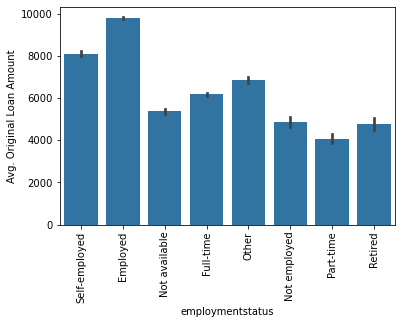

```python
# Make a plot for loan original amount and employment status

sb.barplot(data = prosper_loan, x = 'employmentstatus', y = 'loanoriginalamount', color = base_color)
plt.ylabel('Avg. Original Loan Amount')
plt.xticks(rotation=90);
```

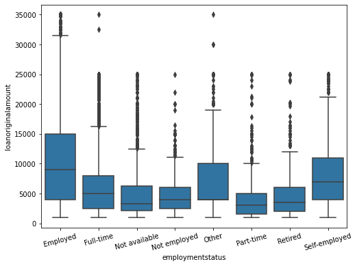

```python
#Investigating further with a boxplot
box_plot('employmentstatus', 'loanoriginalamount', 'employmentstatus')
plt.xticks(rotation=15);
```

> From the adapted barchart, large amount of loans were attributed to the employed observation. this could be due to the fact that most persons that applied for loans were employed. Further investigations using the boxplot has shown that both the median and the upper limit of loan amount for the employed observation is the highest.

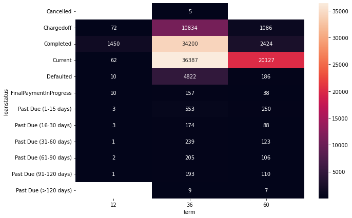

```python
#Checking the interaction between loan status and loan term
#summarising the counts into a matrix that can be plotted via heatmap
ct_counts = prosper_loan.groupby(['loanstatus','term']).size()
ct_counts = ct_counts.reset_index(name = 'count')
#pivot the counts dataframe
ct_counts = ct_counts.pivot(index = 'loanstatus', columns = 'term', values = 'count')

#Plotting the heatmap
heatmap(ct_counts)
```

> Most individuals that had an issue with paying back the loan(those in charged off and defaulted) were more for the medium term loan. From this it could be inferred that although majority went for the middle term loan, it doesn't mean they payback more than those in the short and long term loan. I won't investigate this further.

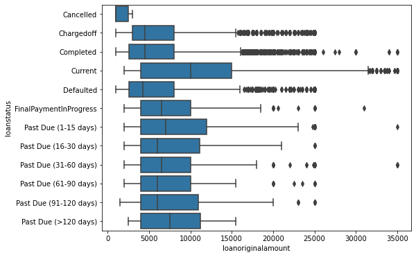

```python
#Checking the interaction between loan status and loan original amount
box_plot('loanoriginalamount', 'loanstatus', 'loanstatus')
```

> Those with current loan status applied for higher loan amounts unlike those that their loan was not approved(cancelled). Does this mean that investors are attracted to high loan amount, as it has been shown above that a positive correlation exists between investors and original loan amount.

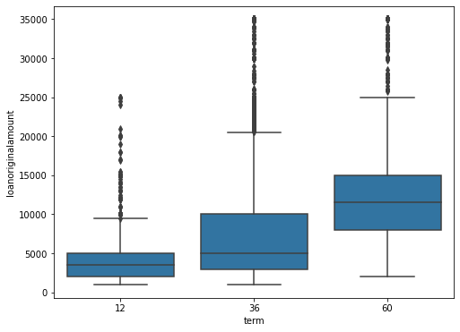

```python
#Checking the interaction between loanoriginalamount and term
box_plot('term', 'loanoriginalamount', 'term')
```

> From the plot we can see that there is a trend of people applying for higher amount of loans given more time(loan term).

## Multivariate Exploration

> Create plots of three or more variables to investigate your data even further. Make sure that your investigations are justified, and follow from your work in the previous sections.

**From the relationship between original loan amount and loan term above, is there any loan status that failed to follow that same pattern?**

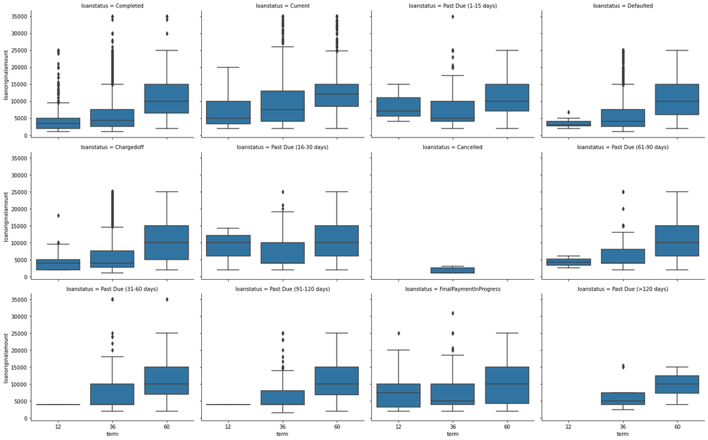

```python
order = prosper_loan.groupby('term').size().index
g = sb.FacetGrid(data = prosper_loan, col = 'loanstatus', col_wrap = 4, aspect = 1.2, height = 4)
g.map(sb.boxplot, 'term', 'loanoriginalamount', order = order);
```

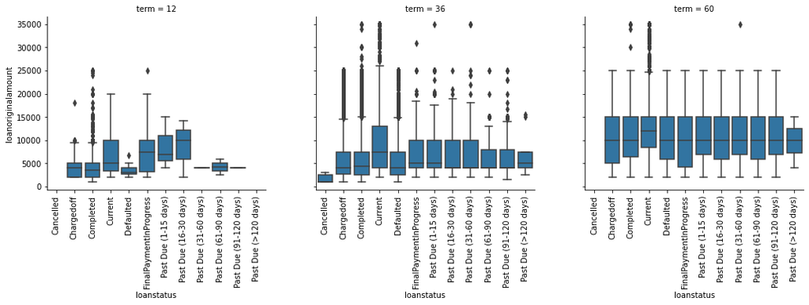

```python
order = prosper_loan.groupby('loanstatus').size().index
g = sb.FacetGrid(data = prosper_loan, col = 'term', col_wrap = 4, aspect = 1.2, height = 4)
g.map(sb.boxplot, 'loanstatus', 'loanoriginalamount', order = order)
g.set_xticklabels(rotation=90);
```

> From the first plot, it can been seen that for each loan status, the median original loan amount for long term loans were still the highest. From the second plot, except for the short term loan, you can see that the median original loan amount was the highest for the current loan status, increasing from the short term loan throgh the medium term to the long term loan.

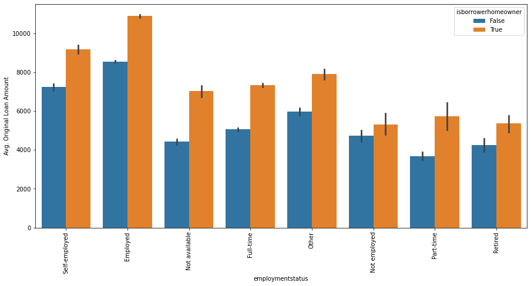

```python
plt.figure(figsize=[15,7])
sb.barplot(data = prosper_loan, x = 'employmentstatus', y = 'loanoriginalamount', hue = 'isborrowerhomeowner')
plt.ylabel('Avg. Original Loan Amount')
plt.xticks(rotation=90);
```

> For each employment status observation, those that are home owners applied for higher amount of loans. I wonder why they do so, despite the fact that they own their homes.

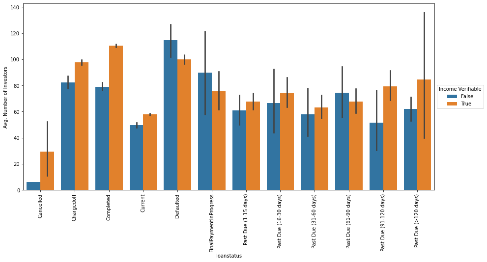

```python
order = prosper_loan.groupby('loanstatus').size().index
plt.figure(figsize=[15,7])
sb.barplot(data = prosper_loan, x = 'loanstatus', y = 'investors', hue = 'incomeverifiable', order = order)
plt.ylabel('Avg. Number of Investors')
plt.legend(loc = 6, bbox_to_anchor = (1.0, 0.5), title = 'Income Verifiable')
plt.xticks(rotation=90);
```

> The average number of investors for those with a verifiable income document is higher for most loan status.

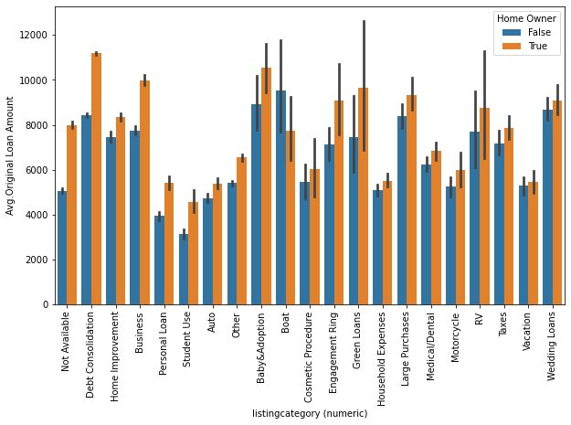

```python
plt.figure(figsize=[10,6])
sb.barplot(data = prosper_loan, x = 'listingcategory (numeric)', y = 'loanoriginalamount', hue = 'isborrowerhomeowner')
locations = [0, 1, 2, 3, 4, 5, 6, 7, 8, 9, 10, 11, 12, 13, 14, 15, 16, 17, 18, 19, 20]
labels = ['Not Available', 'Debt Consolidation', 'Home Improvement', 'Business', 'Personal Loan', 'Student Use', 'Auto',
          'Other', 'Baby&Adoption', 'Boat', 'Cosmetic Procedure', 'Engagement Ring', 'Green Loans', 'Household Expenses',
          'Large Purchases', 'Medical/Dental', 'Motorcycle', 'RV', 'Taxes', 'Vacation', 'Wedding Loans']
plt.xticks(locations, labels, rotation=90)
plt.ylabel('Avg.Original Loan Amount')
plt.legend(title = 'Home Owner');
```

### Were there any interesting or surprising interactions between features?

> I noticed that for each employment status observation, those that are home owners applied for higher amount of loans. Honestly, i wonder why they do so, despite the fact that they own their homes.